# HW PALAWAT 12/1/17

### Binomial Regression Model

We observed seedling survival in a in a forest. At each seedlng, we measure an integrated metric of light levels. We want to estimate a logistic regression model for these data to determine the relationship between light levels and seedlng survival. The model will be of the form: logit(p)<-beta0 + beta1 * light seedling ~ binomial(n=1, p)

Repeat steps 1-6 from the Poisson regression model above except for the binomial model.

Simulating data for a binomial regression.

Simulate data.

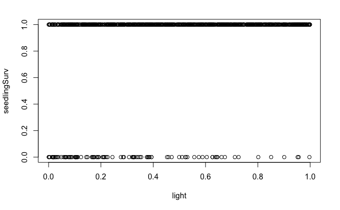

### 1. Fit the Binomial regression using maximum likelihood.

The likelihood function:

```r
nllBinom=function(parVec,sdlgs,lght){
    b0=parVec[1]
    b1=parVec[2]
  sdlgPred=exp(b0+b1*lght)/(1+exp(b0+b1*lght))
  nllik=-sum(dbinom(x=sdlgs,size=1, prob=sdlgPred,log=TRUE))
  return(nllik)
}
```

Maximum likelihood estimates

```r
parVec<-c(.5,.5) # Initial parameter values
outBinom<-optim(par=parVec, fn=nllBinom,method="L-BFGS-B",lower=c(-Inf,-Inf),upper=c(Inf,Inf),sdlgs=seedlingSurv,lght=light)
outBinom$par # .9763, 2.9959
```

```
[1] 0.9763426 2.9959549
```

```r
outBinom$val # 303.3793
```

```
[1] 303.3793
```

```r
myAIC<-2*2 + 2*outBinom$val
myAIC # 610.7586
```

```
[1] 610.7586
```

Plotting Binomial regression fit to the data and showing data points:

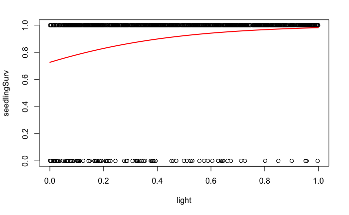

### 2. Compare your maximum likelihood fit to the R glm function. The values are so similar, they could be said to be the same. The maximum likelihood output has more decimal places, so is arguably more exact.

```r
outglm<-glm(seedlingSurv~light, family=binomial,data=seedlingSurvData)
summary(outglm) #.9763, 2.9960
```

```
Call:
glm(formula = seedlingSurv ~ light, family = binomial, data = seedlingSurvData)

Deviance Residuals:
    Min       1Q   Median       3Q      Max
-2.8222   0.2491   0.3568   0.5315   0.7992

Coefficients:
            Estimate Std. Error z value Pr(>|z|)
(Intercept)   0.9763     0.1743   5.603 2.11e-08 ***
light         2.9960     0.4380   6.840 7.90e-12 ***
---
Signif. codes:  0 ‘***’ 0.001 ‘**’ 0.01 ‘*’ 0.05 ‘.’ 0.1 ‘ ’ 1

(Dispersion parameter for binomial family taken to be 1)

    Null deviance: 663.25  on 999  degrees of freedom
Residual deviance: 606.76  on 998  degrees of freedom
AIC: 610.76

Number of Fisher Scoring iterations: 6
```

```r
summary(outStan)
```

```
 Family: bernoulli(logit)
Formula: seedlingSurv ~ light
   Data: seedlingSurvData (Number of observations: 1000)
Samples: 4 chains, each with iter = 2000; warmup = 1000; thin = 1;
         total post-warmup samples = 4000
    ICs: LOO = NA; WAIC = NA; R2 = NA

Population-Level Effects:
          Estimate Est.Error l-95% CI u-95% CI Eff.Sample Rhat
Intercept     0.97      0.17     0.64     1.32       3322 1.00
light         3.03      0.43     2.22     3.91       1762 1.00

Samples were drawn using sampling(NUTS). For each parameter, Eff.Sample
is a crude measure of effective sample size, and Rhat is the potential
scale reduction factor on split chains (at convergence, Rhat = 1).
```

```r
summary(outStan1)
```

```
 Family: bernoulli(logit)
Formula: seedlingSurv ~ light
   Data: seedlingSurvData (Number of observations: 1000)
Samples: 4 chains, each with iter = 2000; warmup = 1000; thin = 1;
         total post-warmup samples = 4000
    ICs: LOO = NA; WAIC = NA; R2 = NA

Population-Level Effects:
          Estimate Est.Error l-95% CI u-95% CI Eff.Sample Rhat
Intercept     0.97      0.17     0.65     1.32       3114 1.00
light         3.03      0.44     2.19     3.90       1615 1.00

Samples were drawn using sampling(NUTS). For each parameter, Eff.Sample
is a crude measure of effective sample size, and Rhat is the potential
scale reduction factor on split chains (at convergence, Rhat = 1).
```

```r
plot(outStan1)
```

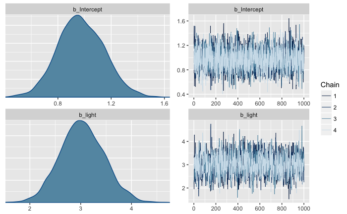

```r
plot(outStan)
```

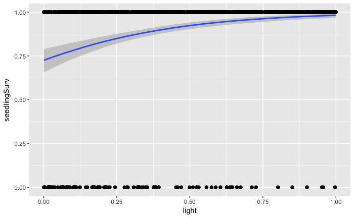

```r
plot(marginal_effects(outStan1), points = TRUE)
```

```r
library(rstanarm)
outrstanarm<-stan_glm(seedlingSurv ~ light,data = seedlingSurvData, family = binomial, iter=2000, warmup=1000, cores=4)
```

[output not shown]

[output not shown]

[output not shown]

[output not shown]

[output not shown]

[output not shown]

[output not shown]

[output not shown]

[output not shown]

[output not shown]

```r
summary(outrstanarm)
```

```
Model Info:

 function:  stan_glm
 family:    binomial [logit]
 formula:   seedlingSurv ~ light
 algorithm: sampling
 priors:    see help('prior_summary')
 sample:    4000 (posterior sample size)
 num obs:   1000

Estimates:
                mean   sd     2.5%   25%    50%    75%    97.5%
(Intercept)      1.0    0.2    0.6    0.9    1.0    1.1    1.3
light            3.0    0.4    2.2    2.7    3.0    3.3    3.9
mean_PPD         0.9    0.0    0.9    0.9    0.9    0.9    0.9
log-posterior -308.6    1.1 -311.4 -309.0 -308.3 -307.9 -307.6

Diagnostics:
              mcse Rhat n_eff
(Intercept)   0.0  1.0  2659
light         0.0  1.0  1566
mean_PPD      0.0  1.0  3076
log-posterior 0.0  1.0  1197

For each parameter, mcse is Monte Carlo standard error, n_eff is a crude measure of effective sample size, and Rhat is the potential scale reduction factor on split chains (at convergence Rhat=1).
```

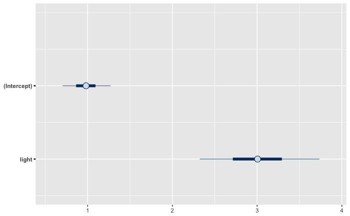

```r
plot(outrstanarm)
```

### 5. Fit the Binomial regression using Rstan.

Write Data

```r
library(rstan)
myData<-list(seedlingSurv=seedlingSurv,light=light,N=length(light))
```

Write Model String

```r
modelString<-"data {
  int<lower=0> N;
  real<lower=0,upper=1> light[N];
  int<lower=0> seedlingSurv[N];
}

parameters {
  real beta0;
  real beta1;
}

transformed parameters {
  real lp[N];
  real <lower=0> mu[N];

  for(i in 1:N){
    lp[i] = beta0 + beta1 * light[i];
    mu[i] = exp(lp[i])/(1+exp(lp[i]));
  }
}

model {
  seedlingSurv ~ binomial(1, mu);
}"
```

Run chains

```r
resStan <- stan(model_code = modelString, data = myData,
                chains = 3, iter = 3000, warmup = 500, thin = 10)
```

[output not shown]

[output cut: 79 more lines]

[output not shown]

```r
summary(resStan,par=c('beta0','beta1'))
```

```
$summary
           mean     se_mean        sd      2.5%       25%       50%      75%    97.5%    n_eff     Rhat
beta0 0.9778513 0.007431832 0.1792232 0.6251021 0.8534177 0.9784645 1.096231 1.303101 581.5629 1.005192
beta1 3.0257408 0.018029410 0.4478946 2.1530189 2.7210583 3.0205164 3.333715 3.889277 617.1469 1.003656

$c_summary
, , chains = chain:1

         stats
parameter      mean        sd      2.5%      25%       50%      75%    97.5%
    beta0 0.9795389 0.1714724 0.6713721 0.850584 0.9744113 1.094624 1.308344
    beta1 2.9909263 0.4171399 2.1469495 2.716517 2.9961158 3.227372 3.787793

, , chains = chain:2

         stats
parameter      mean        sd      2.5%       25%       50%      75%    97.5%
    beta0 0.9611032 0.1791509 0.6108391 0.8488682 0.9599243 1.070273 1.282427
    beta1 3.0801254 0.4583343 2.2571908 2.7705158 3.0959977 3.383288 3.926171

, , chains = chain:3

         stats
parameter      mean        sd     2.5%       25%       50%      75%    97.5%
    beta0 0.9929117 0.1860399 0.628874 0.8710904 0.9921254 1.118526 1.303541
    beta1 3.0061708 0.4634575 2.121492 2.6670624 2.9926218 3.346749 3.934488
```

Generate (a ton) of graphs displaying traceplots and density plots. All the graphs kept screwing up my markdown file so I left them un-run here. But this piece of code does work and I did look through some of the graphs to make sure they were traceplots and density plots.

```r
library(coda)
post_fit<-As.mcmc.list(resStan)
plot(post_fit)
```

### 6. Fit the Binomial regression using Rjags

Write model string to text file.

```r
library(rjags)
modelString<-"
model {
  for (i in 1:N){
    seedlingSurv[i] ~ dbin(p[i], 1)
    logit(p[i]) <- beta0 + beta1 * light[i]
  }
  beta0 ~ dnorm(0, .0001)
  beta1 ~ dnorm(0, .0001)
}
"
writeLines(modelString, con='binomialReg.jags.txt')
```

Run chains.

```r
jags <- jags.model('binomialReg.jags.txt',
                   data = list('seedlingSurv' = seedlingSurv,
                               'light' = light,
                               'N' = length(light)),
                   inits<-list(
                       list('beta0'=1,'beta1'=2),
                       list('beta0'=1,'beta1'=.2),
                       list('beta0'=.1,'beta1'=2),
                       list('beta0'=2,'beta1'=5)),
                   n.chains = 4,
                   n.adapt = 100)
```

[output not shown]

Burn in and estimates.

```r
update(jags, 1000)
```

[output not shown]

```r
jags.samples(jags,
             c('beta0', 'beta1'),
             10000)
```

[output not shown]

Use coda library to plot estimate MCMCs.

```r
library(coda)
codaSamples<-coda.samples(jags, c('beta0','beta1'), 10000, 1)
```

[output not shown]

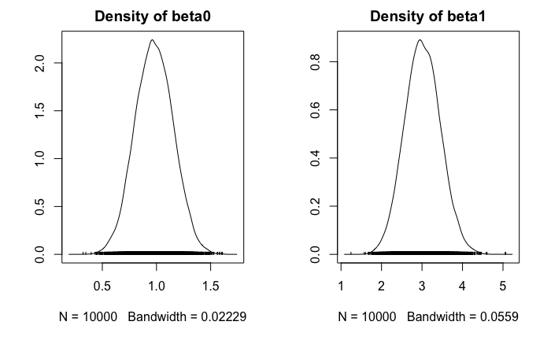

```r
plot(codaSamples, trace = FALSE, density = TRUE)
summary(codaSamples)
```

```
Iterations = 11101:21100
Thinning interval = 1
Number of chains = 4
Sample size per chain = 10000

1. Empirical mean and standard deviation for each variable,
   plus standard error of the mean:

        Mean    SD  Naive SE Time-series SE
beta0 0.9792 0.175 0.0008752       0.002283
beta1 3.0163 0.439 0.0021952       0.005600

2. Quantiles for each variable:

        2.5%    25%    50%   75% 97.5%
beta0 0.6403 0.8585 0.9773 1.099 1.321
beta1 2.1758 2.7143 3.0081 3.311 3.894
```

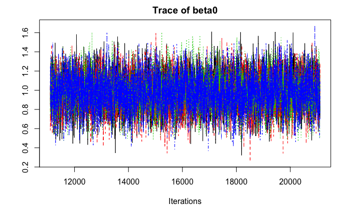

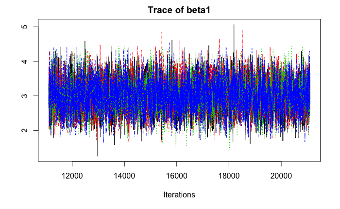

```r
traceplot(codaSamples)
```

I want to say that this has been one of my favorite assignments this semester. I really liked learning all these different methods to simulate regressions and fit data. It is also interesting comparing the outputs to all the different methods when they all have the same inputs.